# Resultados da Primeira Avaliación IES Muralla Romana. Curso 2021-2022.

02-12-2021

# Primeira Avaliación IES Muralla Romana. Curso 2021-2022.

02/12/2021

# 1 Gráficos integrados para os cursos de ESO e BAC por trimestres

**A porcentaxe de alumnos de ESO que aprobaron todas as materias no 1º Trimestre foi do 29.2%, o 34.7% suspenderon entre 1 e 3 materias, o 18.8% entre 4 e 6 materias e o 17.3% suspenderon 7 ou mais materias.**

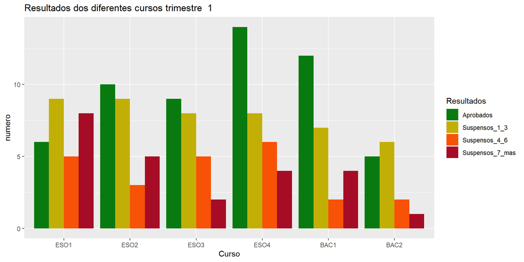

# 2 Gráficos de barras para cada trimestre e cada unha das clases agrupadas por niveis

Nestas gráficas amósanse para cada clase, trimestre e categorías (resultados académicos) as porcentaxes.

**Para o caso dos alumnos de BAC, aprobaron todas as materias no 1º Trimestre o 43.6%, o 33.3% suspenderon entre 1 e 3 materias, o 10.3% entre 4 e 6 materias e o 12.8% suspenderon 7 ou mais materias.**

[figure not shown]

# 2 Gráficos de barras para cada trimestre e cada unha das clases agrupadas por niveis

Nestes gráficos amósanse para cada clase, trimestre e categorías (resultados académicos) as porcentaxes.

## 2.1 Resultados para as clases de ESO

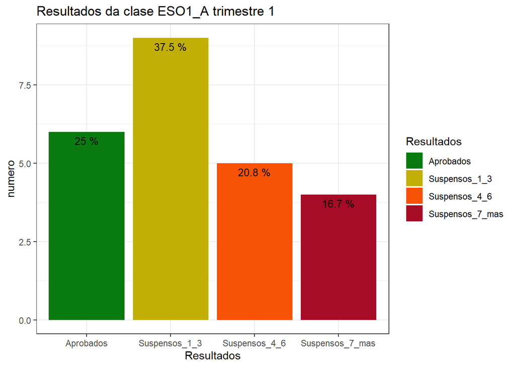

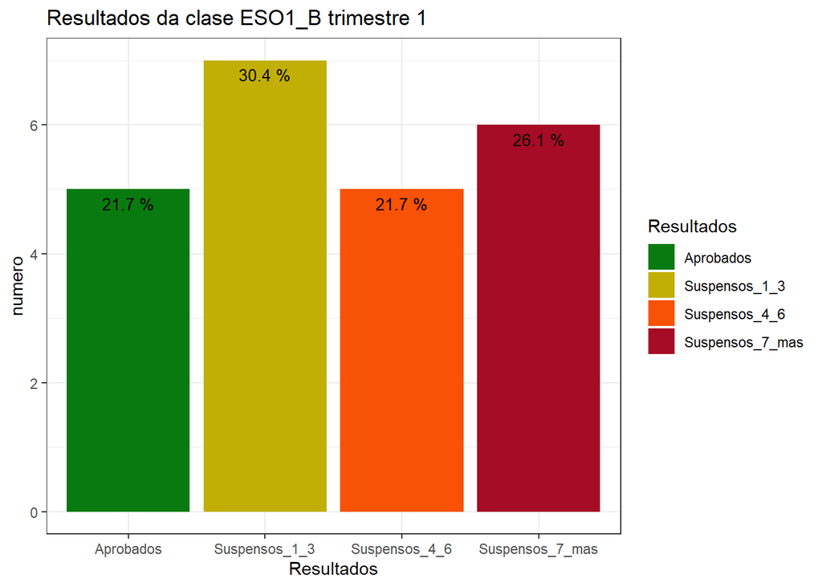

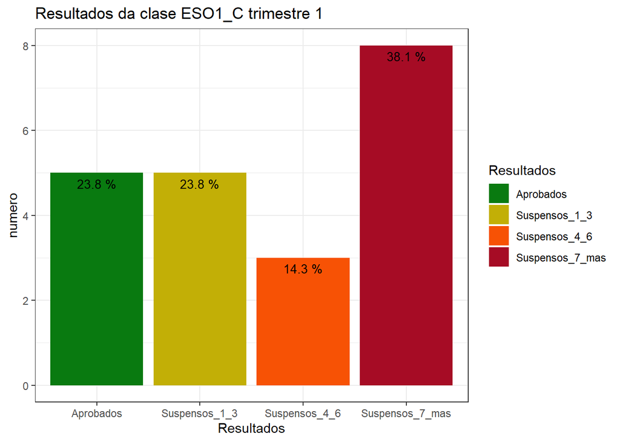

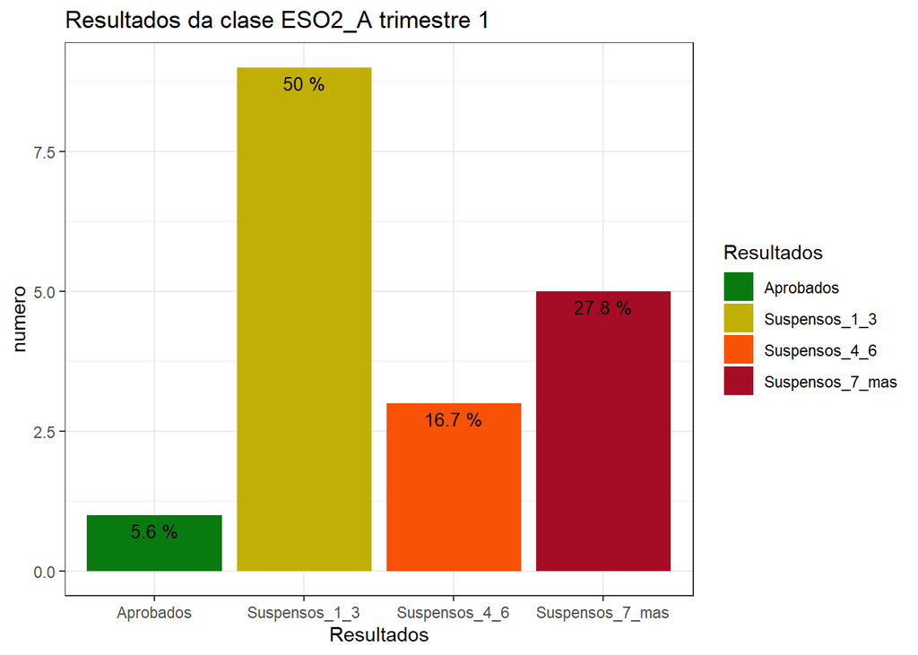

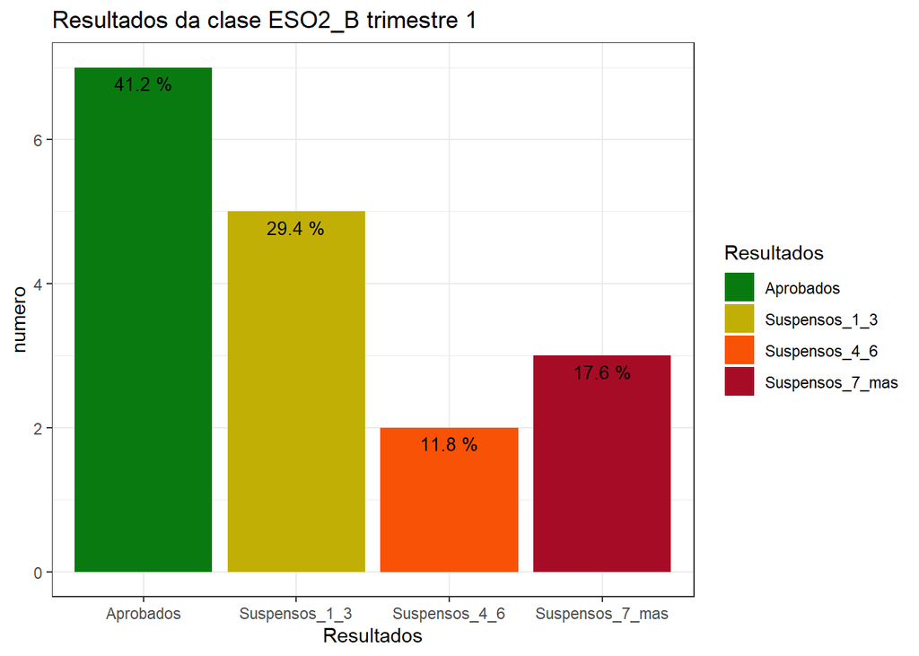

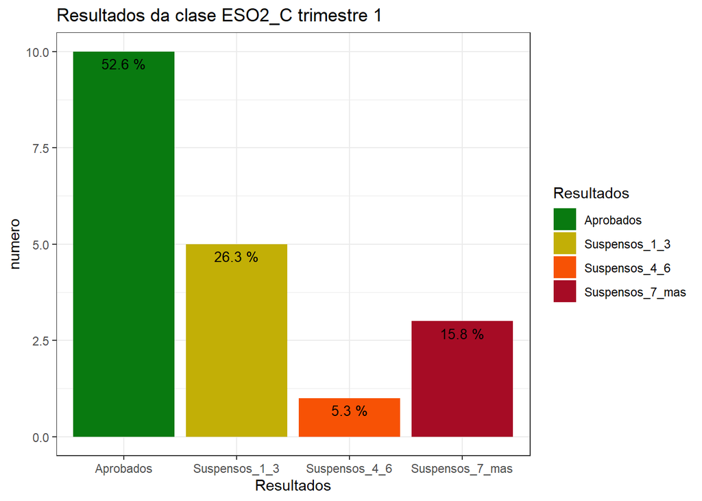

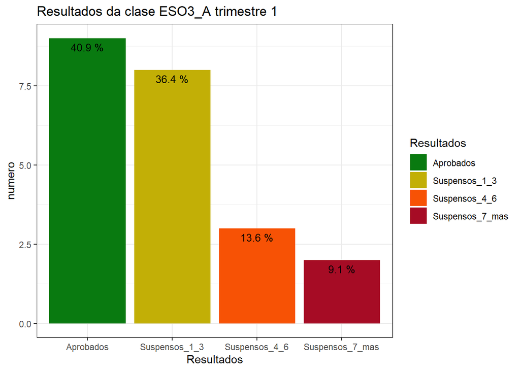

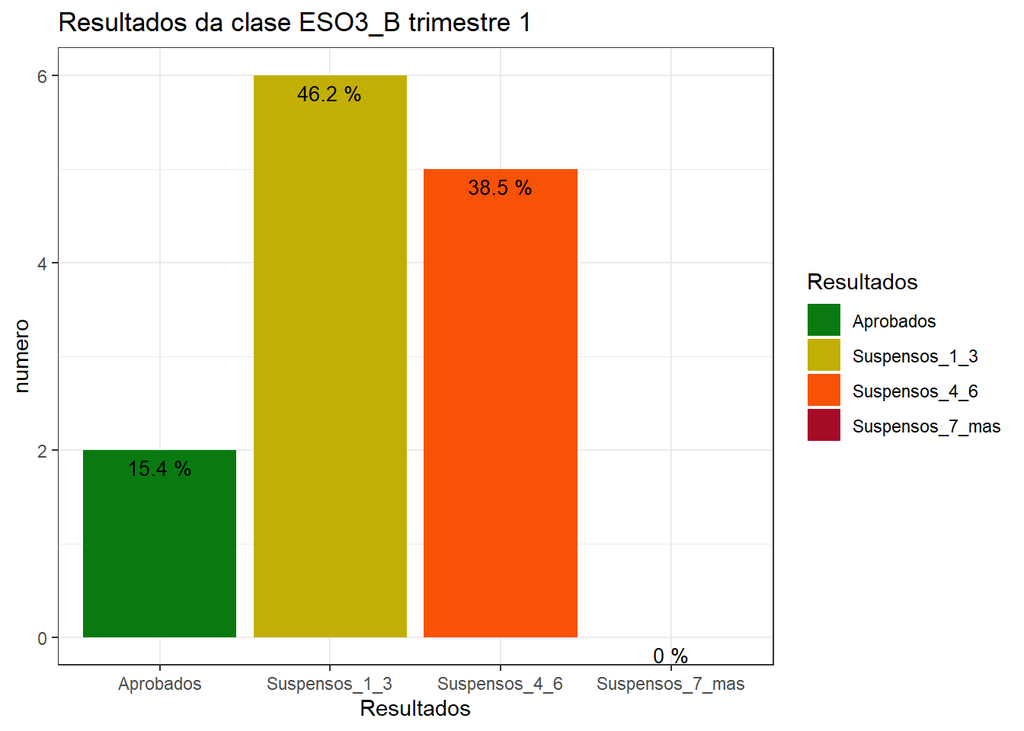

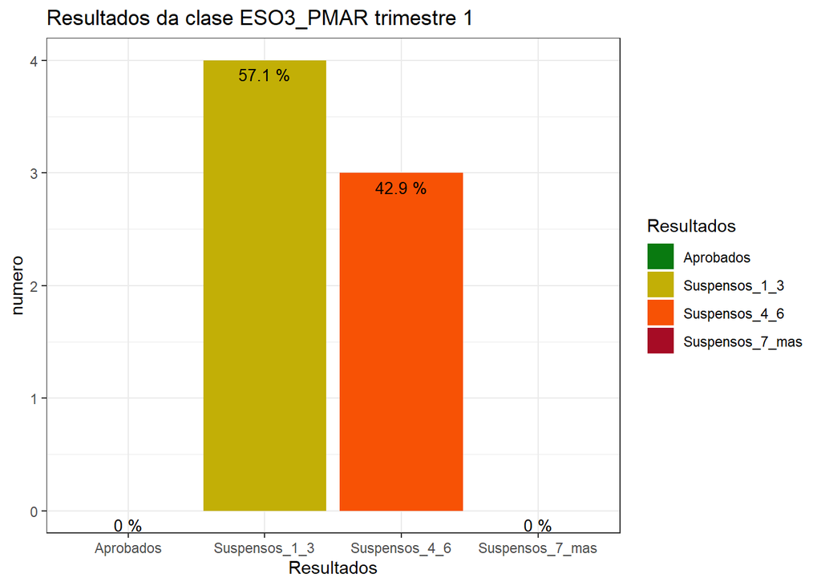

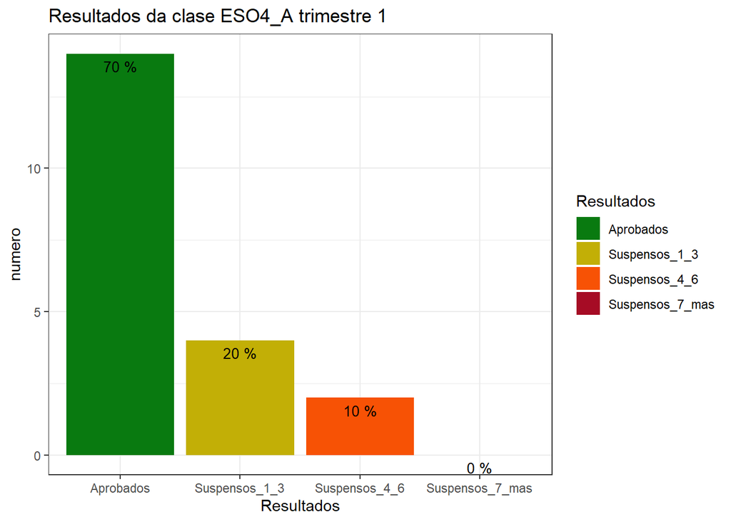

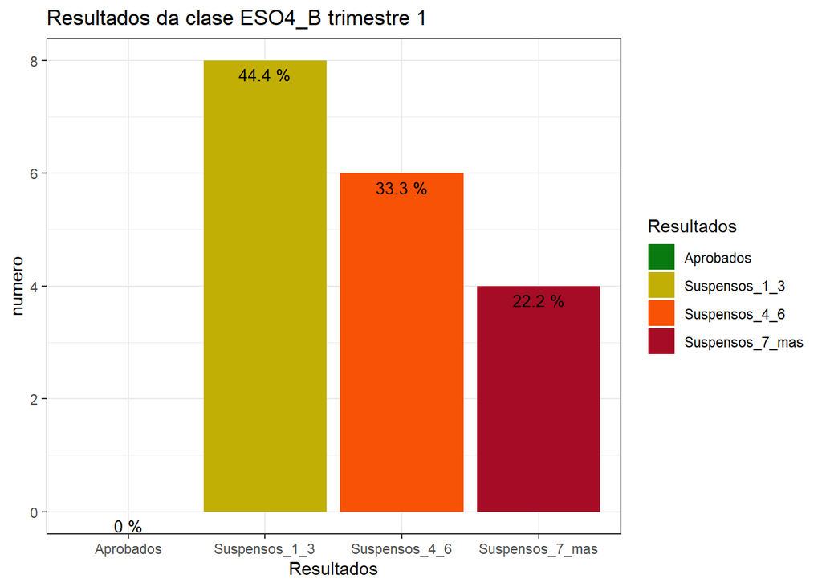

## 2.2 Resultados para as clases de BAC

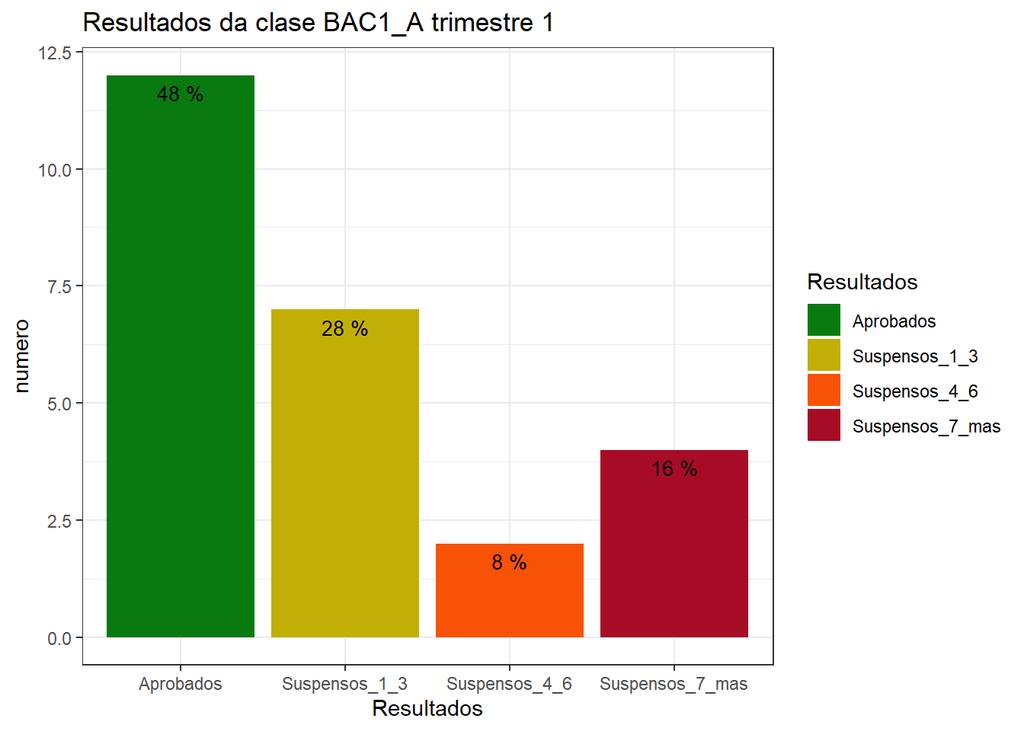

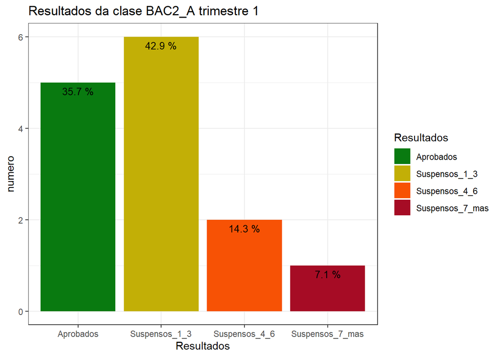

# 3 Graficos dos resultados por clases e trimestres para ESO e BAC.

Nestas gráficas amósanse o número de alumnos por clase e trimestre distribuídos por resultados académicos nun diagrama de barras.

## 3.1 Resultados por trimestre para as clases de ESO

Nestes gráficos amósanse o número de alumnos por clase e trimestre distribuídos por resultados académicos nun diagrama de barras.

## 3.1 Móstranse os resultados por trimestre para as clases de ESO

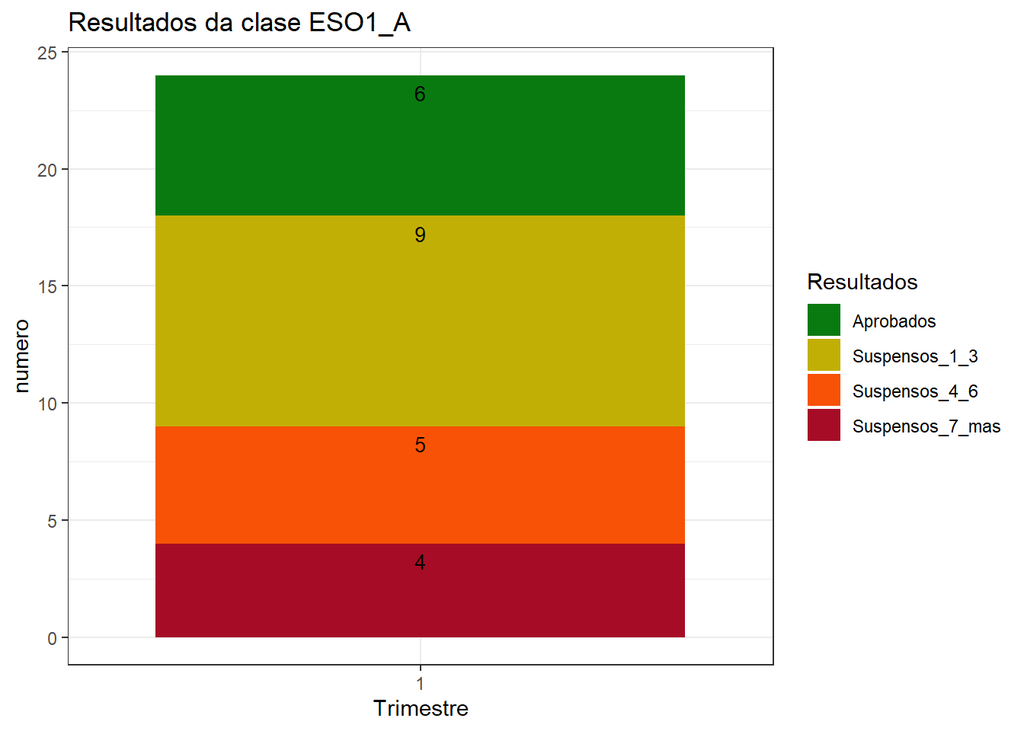

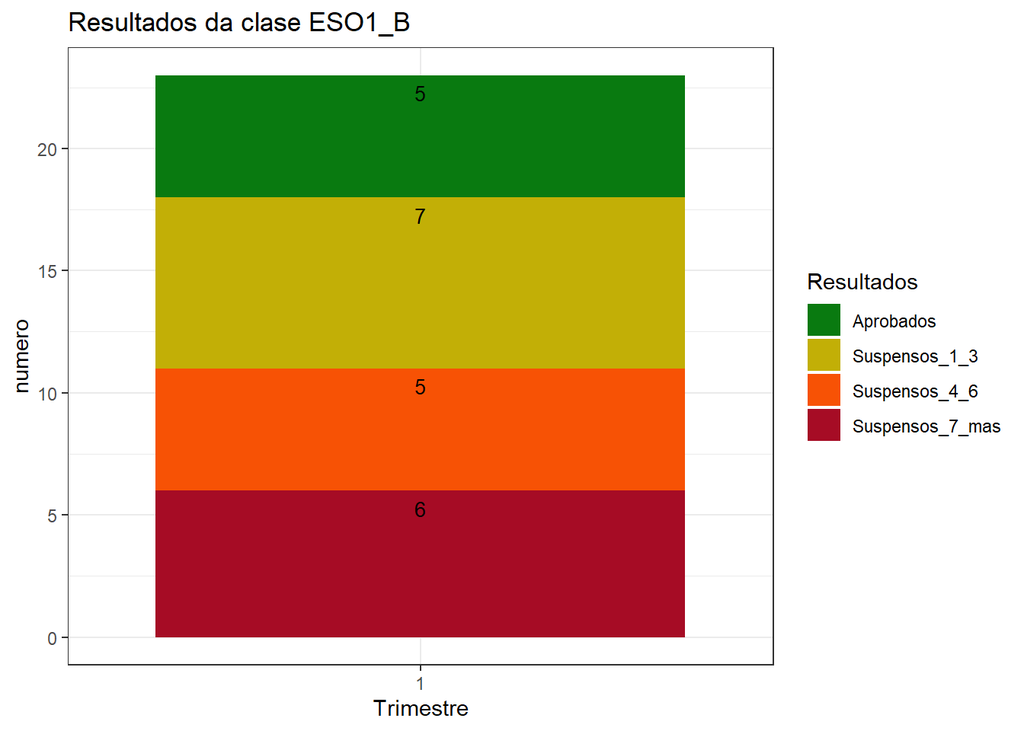

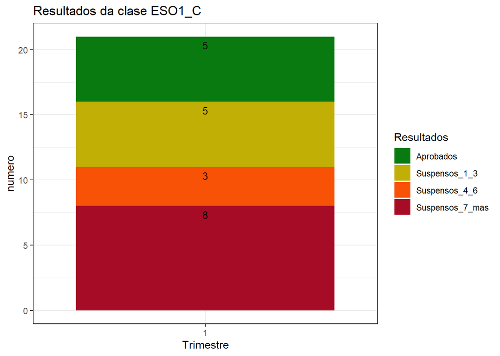

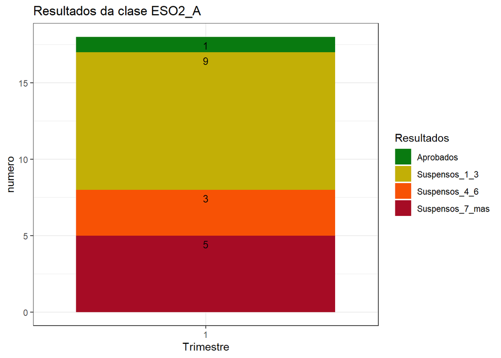

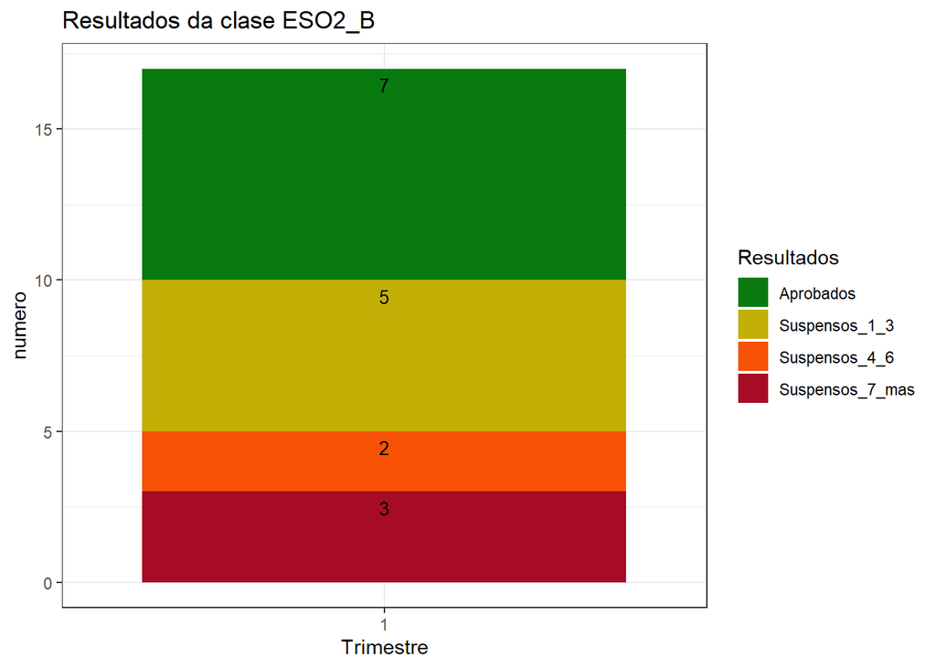

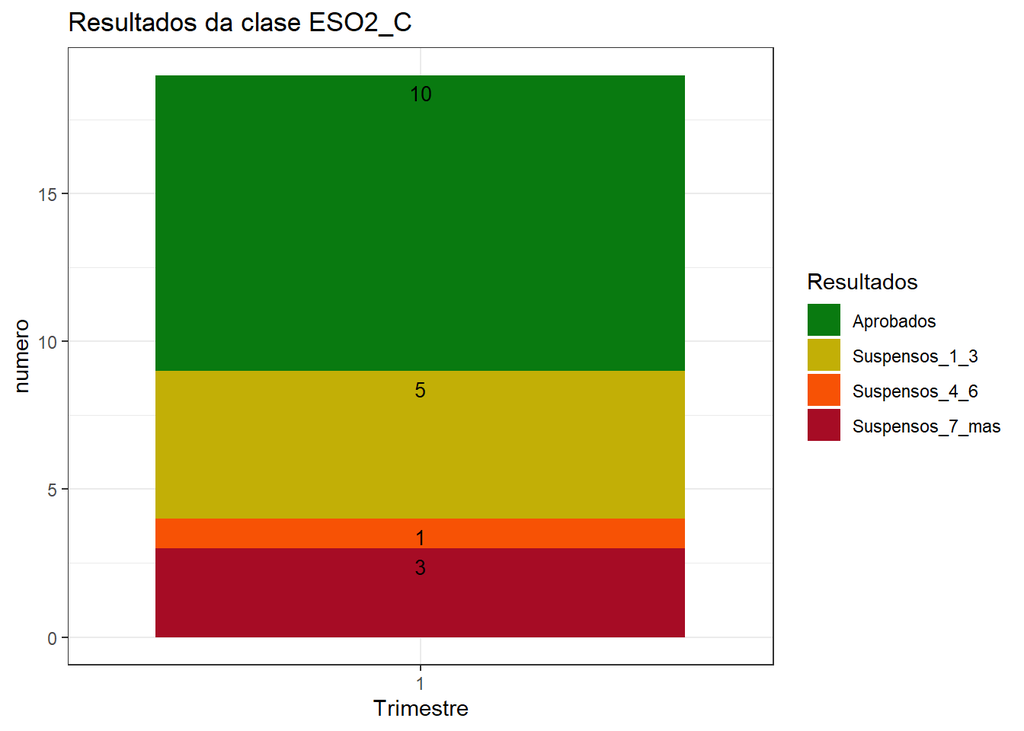

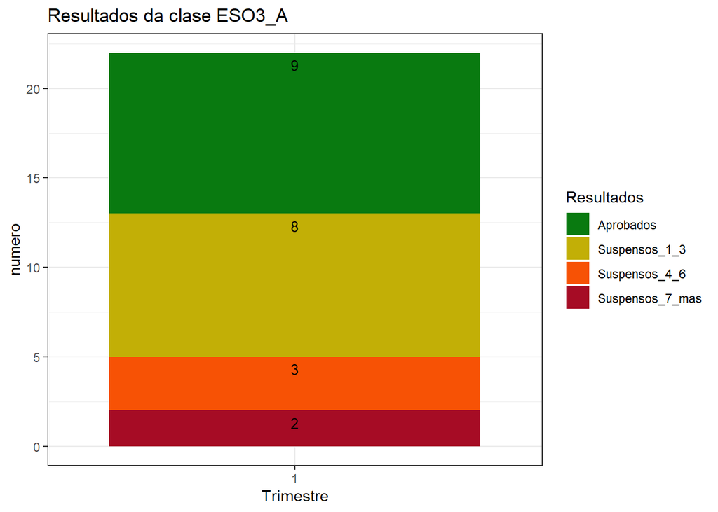

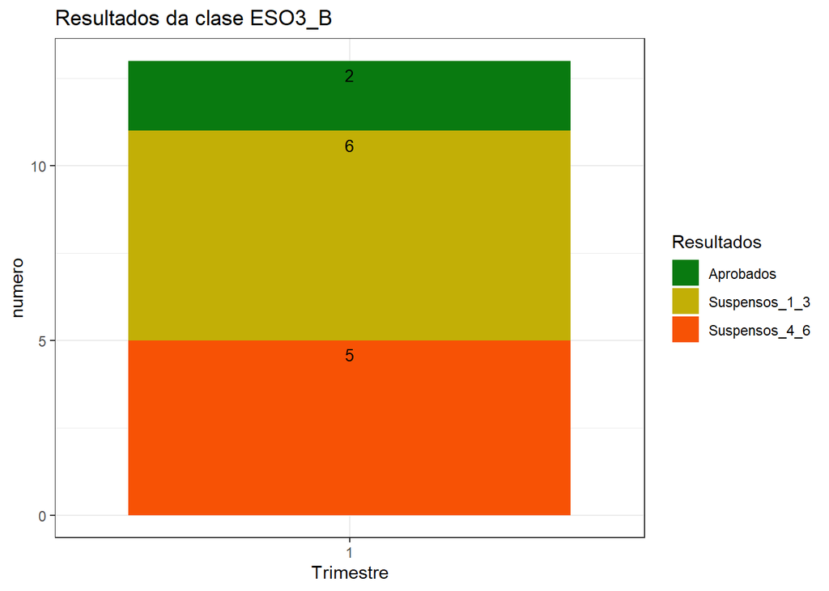

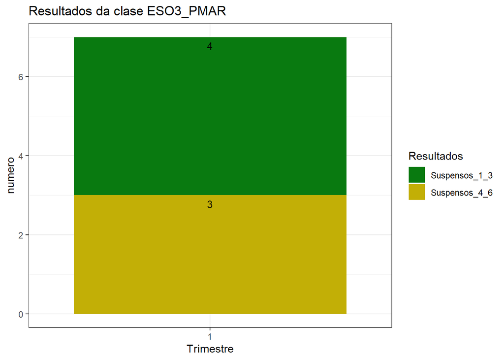

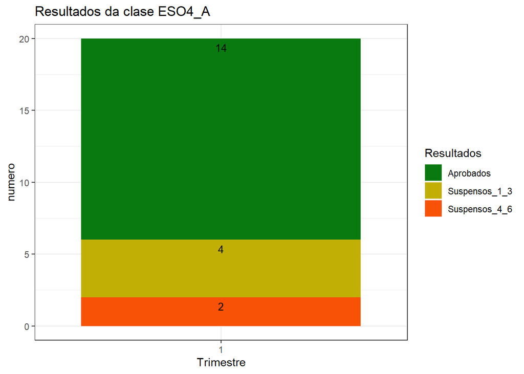

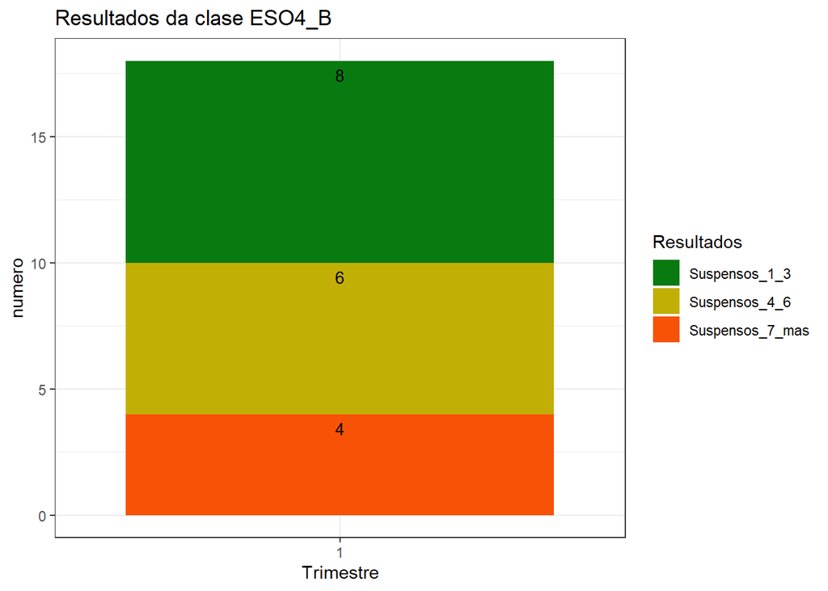

## 3.2 Móstranse os resultados por trimestre para as clases de BAC

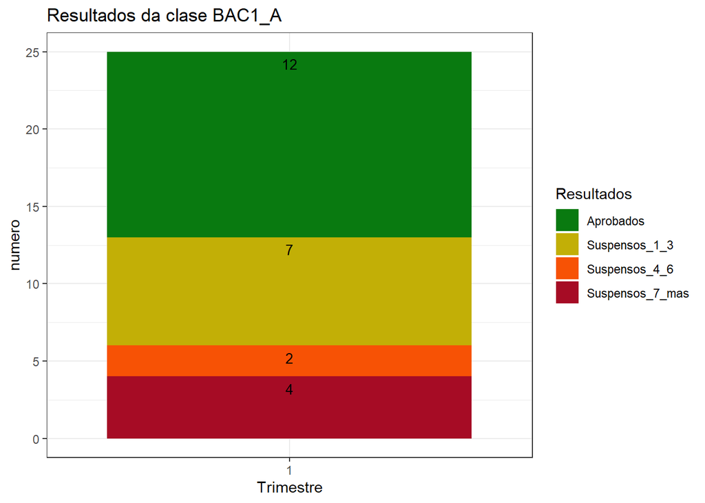

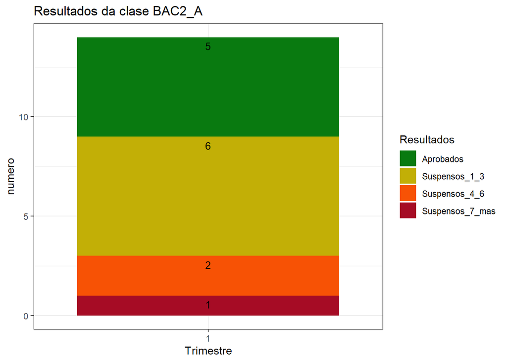

# 4 Gráficos integrados para os cursos de INFOFI e PEIEST por trimestres

**A porcentaxe de alumnos de INFOFI que aprobaron todas as materias no 1º Trimestre foi do 47.8%, o 34.8% suspenderon entre 1 e 3 materias, e o 17.4% 4 ou mais materias.**

**Para o caso dos alumnos de PEIEST a porcentaxe dos alumnos que aprobaron todas as materias foi do 16.7%, o 70.8% suspenderon entre 1 e 3 materias, e o 12.5% 4 ou mais materias.**

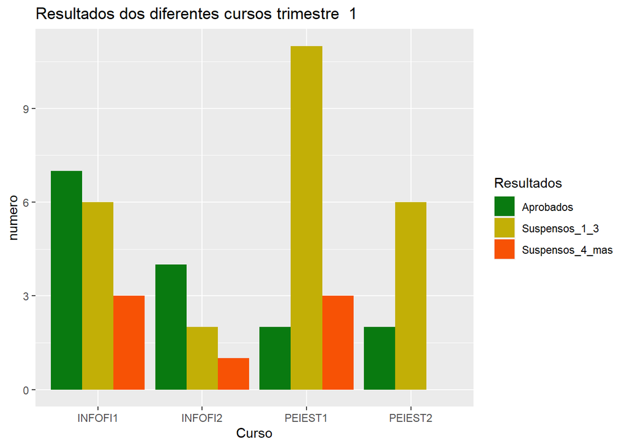

## 4.1 Gráficos para as clases de INFOFI

Nestas gráficas amósanse para cada clase, trimestre e categorías (resultados académicos) as porcentaxes.

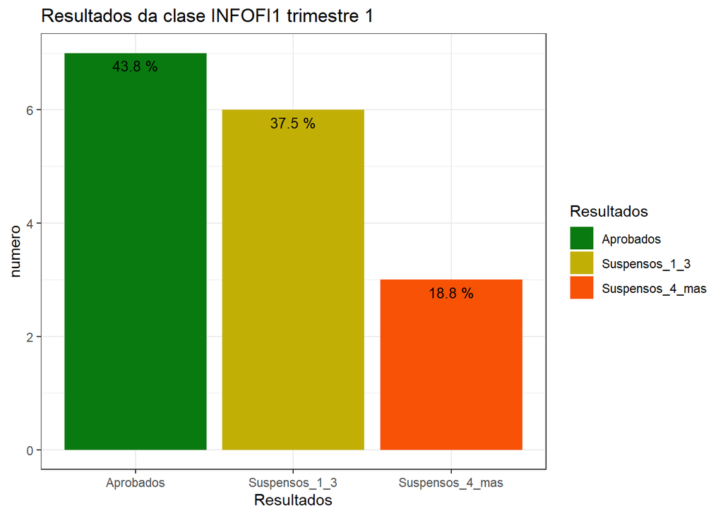

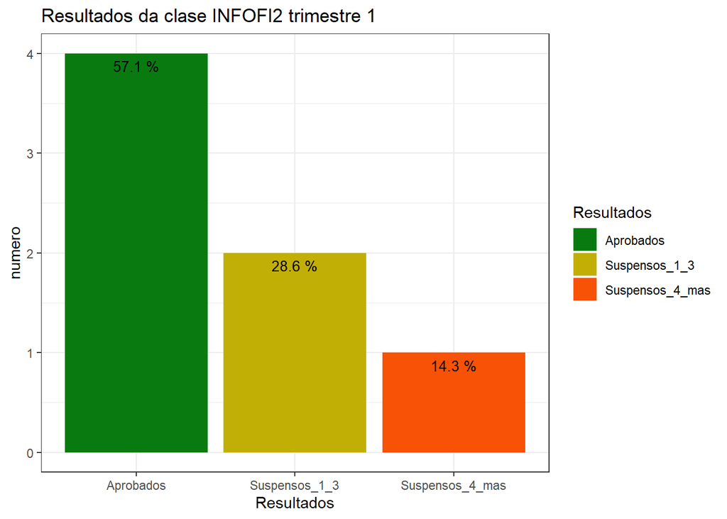